# Simulação de Monte Carlo para Avaliação de uma Opção Call Europeia

Pedro Jesus

2026-03-06

# 1 Introdução

Este relatório estima o valor justo de uma **opção call europeia** sobre a ação da Rheinmetall AG (RHM.DE) utilizando **Simulação de Monte Carlo** baseada no Movimento Browniano Geométrico (GBM).

Os objetivos principais são:

- Simular o preço do ativo sob medida neutra ao risco
- Comparar com o modelo analítico de **Black-Scholes**
- Aplicar técnicas de **redução de variância**: Antithetic Variates, Control Variates e Importance Sampling
- Analisar **intervalos de confiança** e convergência

# 2 Enquadramento Teórico

## 2.1 Movimento Browniano Geométrico (GBM)

O preço do ativo segue a equação diferencial estocástica:

$$dS_t = \mu S_t dt + \sigma S_t
dW_t$$

cuja solução analítica, sob a medida neutra ao risco, é:

$$S_T = S_0 \cdot \exp\left[\left(r -
\frac{1}{2}\sigma^2\right)T + \sigma\sqrt{T}\, Z\right], \quad Z \sim
\mathcal{N}(0,1)$$

## 2.2 Modelo de Black-Scholes

O preço teórico de uma opção call europeia é dado por:

$$C = S_0 N(d_1) - K e^{-rT}
N(d_2)$$

onde:

$$d_1 = \frac{\ln(S_0/K) + (r +
\frac{1}{2}\sigma^2)T}{\sigma\sqrt{T}}, \qquad d_2 = d_1 -
\sigma\sqrt{T}$$

e $N(\cdot)$ é a função de distribuição acumulada da normal padrão.

## 2.3 Estimador de Monte Carlo

O preço da opção é estimado como:

$$\hat{C}_0 = e^{-rT} \cdot \frac{1}{N}
\sum_{i=1}^{N} \max(S_T^{(i)} - K,\, 0)$$

# 3 Parametrização

```r
S0    <- 1736      # Preço inicial da Rheinmetall AG (29/10/2025)
r     <- 0.035     # Taxa livre de risco (3.5% — aproximação à Euribor 3M de out. 2025)
T     <- 0.25      # Horizonte temporal: 3 meses
sigma <- 0.40      # Volatilidade histórica anualizada (estimada sobre retornos diários 2024-2025)

K_list <- c(1.1 * S0, S0, 0.9 * S0)   # OTM, ATM, ITM
names(K_list) <- c("OTM", "ATM", "ITM")

N <- 1000000       # Número de simulações
set.seed(12345)    # Semente para reprodutibilidade
```

A volatilidade $\sigma = 0.40$ corresponde à volatilidade histórica anualizada da Rheinmetall AG, estimada a partir dos retornos logarítmicos diários no período 2024–2025. A Rheinmetall apresentou volatilidade elevada neste período devido à forte exposição ao ciclo de defesa europeu, tornando este valor representativo do risco do ativo. A taxa livre de risco $r = 3.5\%$ é uma aproximação à Euribor a 3 meses vigente em outubro de 2025.

# 4 Funções Base

## 4.1 Black-Scholes Analítico

```r
bs_call <- function(S0, K, r, sigma, T) {
  d1 <- (log(S0 / K) + (r + 0.5 * sigma^2) * T) / (sigma * sqrt(T))
  d2 <- d1 - sigma * sqrt(T)
  S0 * pnorm(d1) - K * exp(-r * T) * pnorm(d2)
}
```

## 4.2 Simulação de Preços Terminais (GBM)

```r
sim_terminal_prices <- function(S0, r, sigma, T, N) {
  Z  <- rnorm(N)
  S0 * exp((r - 0.5 * sigma^2) * T + sigma * sqrt(T) * Z)
}
```

# 5 Monte Carlo Baseline

```r
mc_baseline <- function(S0, K, r, sigma, T, N) {
  ST        <- sim_terminal_prices(S0, r, sigma, T, N)
  payoff    <- pmax(ST - K, 0)
  discounted <- exp(-r * T) * payoff
  est <- mean(discounted)
  se  <- sd(discounted) / sqrt(N)
  ci  <- est + c(-1, 1) * qnorm(0.975) * se
  list(est = est, se = se, ci = ci)
}
```

### 5.0.1 Resultados Baseline vs. Black-Scholes

```r
resultados_baseline <- do.call(rbind, lapply(seq_along(K_list), function(i) {
  K      <- K_list[i]
  bs     <- bs_call(S0, K, r, sigma, T)
  mc     <- mc_baseline(S0, K, r, sigma, T, N)
  data.frame(Strike = names(K_list)[i], BS = bs, MC = mc$est, SE = mc$se, Dif = mc$est - bs)
}))

knitr::kable(resultados_baseline, digits = 4,
             col.names = c("Strike", "BS (€)", "MC (€)", "SE", "Dif. (€)"),
             caption = "Baseline vs. Black-Scholes",  row.names = FALSE)
```

Baseline vs. Black-Scholes

| Strike | BS (€) | MC (€) | SE | Dif. (€) |
| --- | --- | --- | --- | --- |
| OTM | 79.3265 | 79.6323 | 0.1779 | 0.3058 |
| ATM | 145.3731 | 145.0694 | 0.2329 | -0.3037 |
| ITM | 245.0693 | 245.3329 | 0.2859 | 0.2636 |

A simulação com 1 milhão de trajetórias converge para o preço teórico de Black-Scholes com diferenças inferiores a €0.31 em todos os strikes.

# 6 Técnicas de Redução de Variância

## 6.1 Antithetic Variates

Utiliza pares de variáveis opostas $(Z_i, -Z_i)$, introduzindo correlação negativa entre os pares de payoffs e reduzindo a variância do estimador.

```r
mc_antithetic <- function(S0, K, r, sigma, T, N) {
  Z   <- rnorm(N / 2)
  ST  <- S0 * exp((r - 0.5 * sigma^2) * T + sigma * sqrt(T) * c(Z, -Z))
  discounted <- exp(-r * T) * pmax(ST - K, 0)
  est <- mean(discounted)
  se  <- sd(discounted) / sqrt(N)
  ci  <- est + c(-1, 1) * qnorm(0.975) * se
  list(est = est, se = se, ci = ci)
}
```

## 6.2 Control Variates

Utiliza uma variável auxiliar com valor esperado conhecido para corrigir o estimador:

$$\hat{C}_{CV} = \bar{Y} - b^*(\bar{X} -
\mathbb{E}[X]), \qquad b^* =
\frac{\text{Cov}(Y,X)}{\text{Var}(X)}$$

```r
mc_control_variate <- function(S0, K, r, sigma, T, N) {
  Z  <- rnorm(N)
  ST <- S0 * exp((r - 0.5 * sigma^2) * T + sigma * sqrt(T) * Z)
  Y  <- exp(-r * T) * pmax(ST - K, 0)          # variável de interesse
  X  <- exp(-r * T) * (ST - K)                  # variável de controlo
  b_star <- cov(Y, X) / var(X)
  Y_cv   <- Y - b_star * (X - mean(X))
  est <- mean(Y_cv)
  se  <- sd(Y_cv) / sqrt(N)
  ci  <- est + c(-1, 1) * qnorm(0.975) * se
  list(est = est, se = se, ci = ci, b = b_star)
}
```

## 6.3 Importance Sampling

Desloca a distribuição de amostragem para regiões onde o payoff é positivo, corrigindo pelo likelihood ratio:

$$w_i = \exp\left(-\mu_{\text{shift}}
\cdot Z_i^{\text{shifted}} +
\frac{1}{2}\mu_{\text{shift}}^2\right)$$

O parâmetro $\mu_{\text{shift}} = 1.0$ desloca a média da distribuição de amostragem em +1 desvio padrão, concentrando as simulações em trajetórias onde $S_T > K$. Este valor é razoável para opções ATM e OTM com $\sigma = 0.40$ e $T = 0.25$: um desvio maior aumentaria o peso de trajetórias muito afastadas do strike, amplificando a variância dos pesos de correcção e anulando o ganho de eficiência.

```r
mc_importance <- function(S0, K, r, sigma, T, N, mu_shift = 1.0) {
  Z_shifted <- rnorm(N, mean = mu_shift, sd = 1)
  ST        <- S0 * exp((r - 0.5 * sigma^2) * T + sigma * sqrt(T) * Z_shifted)
  payoff    <- pmax(ST - K, 0)
  weights   <- exp(-mu_shift * Z_shifted + 0.5 * mu_shift^2)   # likelihood ratio
  discounted <- exp(-r * T) * payoff * weights
  est <- mean(discounted)
  se  <- sd(discounted) / sqrt(N)
  ci  <- est + c(-1, 1) * qnorm(0.975) * se
  list(est = est, se = se, ci = ci)
}
```

# 7 Resultados: Comparação dos Métodos

```r
set.seed(12345)

results_df <- data.frame()

for (i in seq_along(K_list)) {
  K        <- K_list[i]
  bs_price <- bs_call(S0, K, r, sigma, T)
  base     <- mc_baseline(S0, K, r, sigma, T, N)
  anti     <- mc_antithetic(S0, K, r, sigma, T, N)
  cv       <- mc_control_variate(S0, K, r, sigma, T, N)
  is_res   <- mc_importance(S0, K, r, sigma, T, N, mu_shift = 1)

  results_df <- rbind(results_df, data.frame(
    Strike      = names(K_list)[i],
    K_val       = K,
    BS          = round(bs_price, 4),
    Baseline    = round(base$est, 4),
    Antithetic  = round(anti$est, 4),
    ControlVar  = round(cv$est, 4),
    Importance  = round(is_res$est, 4),
    SE_Base     = base$se,
    SE_Anti     = anti$se,
    SE_CV       = cv$se,
    SE_IS       = is_res$se,
    Red_Anti    = round(100 * (1 - anti$se / base$se), 2),
    Red_CV      = round(100 * (1 - cv$se / base$se), 2),
    Red_IS      = round(100 * (1 - is_res$se / base$se), 2)
  ))
}

knitr::kable(
  results_df[, c("Strike", "BS", "Baseline", "Antithetic", "ControlVar", "Importance")],
  col.names = c("Strike", "Black-Scholes (€)", "Baseline (€)",
                "Antithetic (€)", "Control Var. (€)", "Importance (€)"),
  caption = "Estimativas de preço por método",  row.names = FALSE
)
```

Estimativas de preço por método

| Strike | Black-Scholes (€) | Baseline (€) | Antithetic (€) | Control Var. (€) | Importance (€) |
| --- | --- | --- | --- | --- | --- |
| OTM | 79.3265 | 79.6323 | 79.3439 | 79.1915 | 79.3862 |
| ATM | 145.3731 | 145.4247 | 145.4933 | 145.5244 | 145.3577 |
| ITM | 245.0693 | 245.0349 | 244.8952 | 245.5126 | 245.0785 |

```r
knitr::kable(
  results_df[, c("Strike", "Red_Anti", "Red_CV", "Red_IS")],
  col.names = c("Strike", "Antithetic (%)", "Control Var. (%)", "Importance (%)"),
  caption = "Redução do erro padrão face ao Baseline (%)",  row.names = FALSE
)
```

Redução do erro padrão face ao Baseline (%)

| Strike | Antithetic (%) | Control Var. (%) | Importance (%) |
| --- | --- | --- | --- |
| OTM | 0.29 | 41.10 | 64.83 |
| ATM | 0.05 | 55.68 | 65.73 |
| ITM | 0.13 | 70.76 | 66.54 |

## 7.1 Gráfico de Erros Padrão

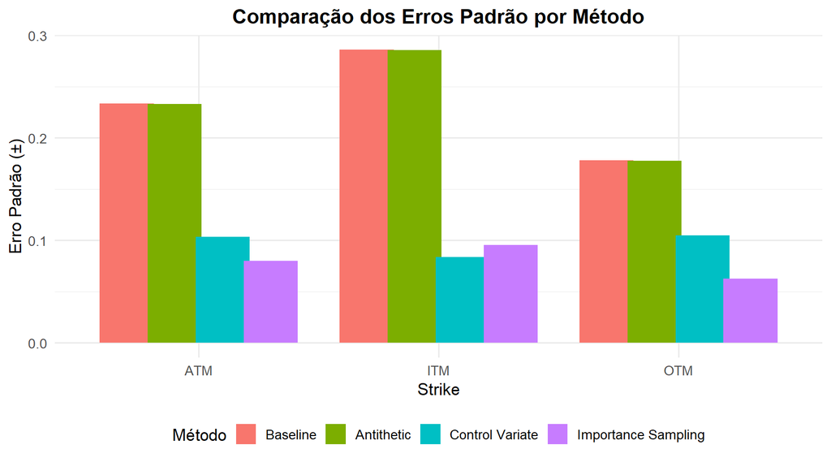

```r
se_df <- data.frame(
  Strike = rep(results_df$Strike, 4),
  Metodo = rep(c("Baseline", "Antithetic", "Control Variate", "Importance Sampling"),
               each = nrow(results_df)),
  SE = c(results_df$SE_Base, results_df$SE_Anti, results_df$SE_CV, results_df$SE_IS)
)
se_df$Metodo <- factor(se_df$Metodo,
                       levels = c("Baseline", "Antithetic", "Control Variate", "Importance Sampling"))

ggplot(se_df, aes(x = Strike, y = SE, fill = Metodo)) +
  geom_bar(stat = "identity", position = position_dodge(width = 0.8)) +
  labs(title = "Comparação dos Erros Padrão por Método",
       x = "Strike", y = "Erro Padrão (±)", fill = "Método") +
  theme_minimal(base_size = 13) +
  theme(plot.title = element_text(hjust = 0.5, face = "bold"),
        legend.position = "bottom")
```

# 8 Intervalos de Confiança a 95%

```r
set.seed(12345)

ic_rows <- list()
for (i in seq_along(K_list)) {
  K    <- K_list[i]
  base <- mc_baseline(S0, K, r, sigma, T, N)
  anti <- mc_antithetic(S0, K, r, sigma, T, N)
  cv   <- mc_control_variate(S0, K, r, sigma, T, N)
  is_r <- mc_importance(S0, K, r, sigma, T, N)
  bs_p <- bs_call(S0, K, r, sigma, T)

  ic_rows[[i]] <- data.frame(
    Strike     = names(K_list)[i],
    BS         = round(bs_p, 4),
    IC_Base    = sprintf("[%.2f, %.2f]", base$ci[1], base$ci[2]),
    IC_Anti    = sprintf("[%.2f, %.2f]", anti$ci[1], anti$ci[2]),
    IC_CV      = sprintf("[%.2f, %.2f]", cv$ci[1],   cv$ci[2]),
    IC_IS      = sprintf("[%.2f, %.2f]", is_r$ci[1], is_r$ci[2])
  )
}

ic_df <- do.call(rbind, ic_rows)
knitr::kable(ic_df,
  col.names = c("Strike", "BS (€)", "Baseline", "Antithetic",
                "Control Var.", "Importance"),
  caption = "Intervalos de Confiança a 95% por método e strike",  row.names = FALSE)
```

Intervalos de Confiança a 95% por método e strike

| Strike | BS (€) | Baseline | Antithetic | Control Var. | Importance |
| --- | --- | --- | --- | --- | --- |
| OTM | 79.3265 | [79.28, 79.98] | [79.00, 79.69] | [78.99, 79.40] | [79.26, 79.51] |
| ATM | 145.3731 | [144.97, 145.88] | [145.04, 145.95] | [145.32, 145.73] | [145.20, 145.51] |
| ITM | 245.0693 | [244.47, 245.59] | [244.34, 245.45] | [245.35, 245.68] | [244.89, 245.27] |